# Convergence of SAEM

Wei Jiang

5/10/2018

Here are R codes to demonstate the convergence of SAEM.

First load all the libraries that we will use.

```r
library(misaem) #https://github.com/wjiang94/misaem
library(MASS)
library(mvtnorm)
library(ggplot2)
library(reshape2)
library(dplyr)
library(RColorBrewer)
theme_set(theme_bw())
```

## Simulation setting

We first generate a design matrix of size $n=1000$ times $p=5$ by drawing each observation from a multivariate normal distribution $\mathcal{N}(\mu, \Sigma)$. Then, we generate the response according to the logistic regression model with coefficients $\beta$.

```r
n <- 1000  # number of subjects
p <- 5     # number of explanatory variables
mu.star <- 1:p  # mean of the explanatory variables
sd <- 1:p # standard deviations
C <- matrix(c(   # correlation matrix
  1,   0.8, 0,   0,   0,
  0.8, 1,   0,   0,   0,
  0,   0,   1,   0.3, 0.6,
  0,   0,   0.3, 1,   0.7,
  0,   0,   0.6, 0.7, 1
), nrow=p)
Sigma.star <- diag(sd)%*%C%*%diag(sd) # variance-covariance matrix of the explanatory variables

beta.star <- c(0.5, -0.3, 1, 0, -0.6) # coefficients of logistic regression
beta0.star <- -0.2  # intercept
beta.true = c(beta0.star,beta.star)

# generate complete design matrix
X.complete <- matrix(rnorm(n*p), nrow=n)%*%chol(Sigma.star) + matrix(rep(mu.star,n), nrow=n, byrow = TRUE)
# generate response vector
p1 <- 1/(1+exp(-X.complete%*%beta.star-beta0.star))
y <- as.numeric(runif(n)<p1)
```

Then we randomly introduce 10% of missing values in the covariates according to the MCAR mechanism.

```r
p.miss <- 0.10
patterns = runif(n*p)<p.miss
X.obs <- X.complete
X.obs[patterns] <- NA
```

After that, with existence of missingness, SAEM can be used for estimating the parameters of the model. By default, the algorithm was initialized with the parameters obtained after mean imputation, i.e. imputing the missing entries with the mean of the variables on observed values and estimating the parameters on the completed data set. For more details and help, type `help(miss.saem)`.

```r
list.saem=miss.saem(X.obs,y,print_iter = FALSE,var_cal = TRUE, ll_obs_cal = TRUE)
cat("Estimated beta: ", '\n', list.saem$beta, '\n')
```

```
## Estimated beta:
##  -0.1352321 0.6755281 -0.4634801 1.057541 0.02840856 -0.6050403
```

```r
cat("Variance-covariance matrix for estimation: ", '\n', list.saem$var_obs, '\n')
```

```
## Variance-covariance matrix for estimation:
##  0.03524877 -0.007593964 -0.001736782 -0.003453993 -0.001602439 0.0003577605 -0.007593964 0.029412 -0.01246823 0.003599761 0.0004862811 -0.002126169 -0.001736782 -0.01246823 0.007708983 -0.002116172 -0.0001939525 0.001241801 -0.003453993 0.003599761 -0.002116172 0.005797672 0.0005341354 -0.003185…
```

```r
cat("Standard error for estimation: ", '\n', list.saem$std_obs, '\n')
```

```
## Standard error for estimation:
##  0.1877466 0.1714993 0.08780082 0.07614245 0.03559032 0.05056067
```

```r
cat("Observed log-likelihood: ", '\n', list.saem$ll, '\n')
```

```
## Observed log-likelihood:
##  -10223.54
```

```r
cat("Execution time: ", '\n', list.saem$time_run, '\n')
```

```
## Execution time:
##  21.89664
```

## Convergence of SAEM

```r
NB = 4 # number of repetitions of simulations
tau <- c(0.6, 0.8, 1)
k1 <- 50
maxruns=500
BIASBETA1_0.6 = BETA1_0.6 = matrix(0, NB, maxruns+1)
BIASBETA1_0.8 = BETA1_0.8 = matrix(0, NB, maxruns+1)
BIASBETA1_1.0 = BETA1_1.0 = matrix(0, NB, maxruns+1)

seed <- c(1,10,100,1000)

for(nb in 1:NB){
  set.seed(seed[nb])
  # ----- complete data
  X.complete <- matrix(rnorm(n*p), nrow=n)%*%chol(Sigma.star) + matrix(rep(mu.star,n), nrow=n, byrow = TRUE)
  p1 <- 1/(1+exp(-X.complete%*%beta.star-beta0.star))
  y <- as.numeric(runif(n)<p1)

  # ------- generating missing data
  X.obs <- X.complete
  patterns = runif(n*p)<p.miss
  X.obs[patterns] <- NA

  # tau = 0.6
  list.saem0.6=miss.saem(X.obs,y,maxruns=maxruns,tol_em=1e-50,tau=tau[1],k1=k1,print_iter=FALSE)
  BETA1_0.6[nb,] = list.saem0.6$seqbeta[2,]
  BIASBETA1_0.6[nb,] = list.saem0.6$seqbeta[2,] - list.saem0.6$beta[2]

  # tau = 0.8
  list.saem0.8=miss.saem(X.obs,y,maxruns=maxruns,tol_em=1e-50,tau=tau[2],k1=k1,print_iter=FALSE)
  BETA1_0.8[nb,] = list.saem0.8$seqbeta[2,]
  BIASBETA1_0.8[nb,] = list.saem0.8$seqbeta[2,] - list.saem0.8$beta[2]

  # tau = 1.0
  list.saem1.0=miss.saem(X.obs,y,maxruns=maxruns,tol_em=1e-50,tau=tau[3],k1=k1,print_iter=FALSE)
  BETA1_1.0[nb,] = list.saem1.0$seqbeta[2,]
  BIASBETA1_1.0[nb,] = list.saem1.0$seqbeta[2,] - list.saem1.0$beta[2]
}
```

Here we produce the convergence plot. Convergence plots for $\beta_1$ obtained with three different values of $\tau$, Each color represents one simulation.

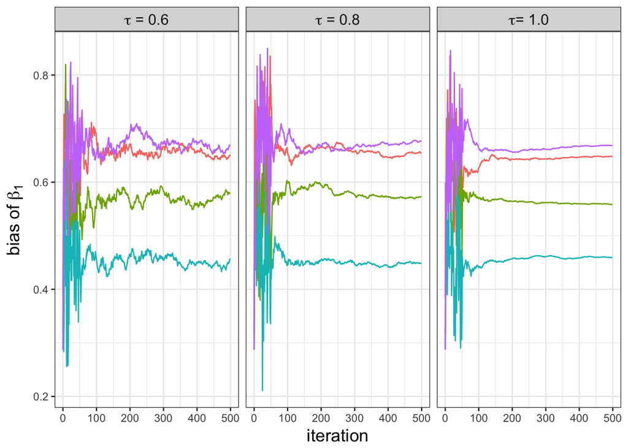

```r
fnames <- c("0.6", "0.8", "1.0")
df1 <- as.data.frame(t(BETA1_0.6))
names(df1) <- 1:NB
df1['iteration'] <- 0:(nrow(df1)-1)
df1 <- melt(df1, variable.name="replicate", id.vars = list("iteration"))
df1['tau'] = fnames[1]
df2 <- as.data.frame(t(BETA1_0.8))
names(df2) <- 1:NB
df2['iteration'] <- 0:(nrow(df2)-1)
df2 <- melt(df2, variable.name="replicate", id.vars = list("iteration"))
df2['tau'] = fnames[2]
df3 <- as.data.frame(t(BETA1_1.0))
names(df3) <- 1:NB
df3['iteration'] <- 0:(nrow(df3)-1)
df3 <- melt(df3, variable.name="replicate", id.vars = list("iteration"))
df3['tau'] = fnames[3]

df <- rbind(df1, df2, df3)
df[['tau']] <- factor(df[['tau']], levels=fnames)
levels(df[['tau']]) <- c("tau*' = 0.6'", "tau*' = 0.8'", "tau*'= 1.0'")

beta2 <- subset(df, iteration==maxruns)
beta1 <- beta2
beta1$iteration <- 0
beta <- rbind(beta1, beta2)

pl <- ggplot(df) + geom_line(aes(iteration,value,color=replicate)) +
  geom_line(data=beta, aes(iteration, value, color=replicate), linetype=3) +
  facet_grid(~tau, labeller = label_parsed) +  ylab(expression(bias~of~beta[1])) +
  theme(strip.text = element_text(size=12), axis.title=element_text(size=14),
        legend.position="none")
print(pl)
```

Convergence plot for all $\beta$ in SAEM. Each color represents one parameter:

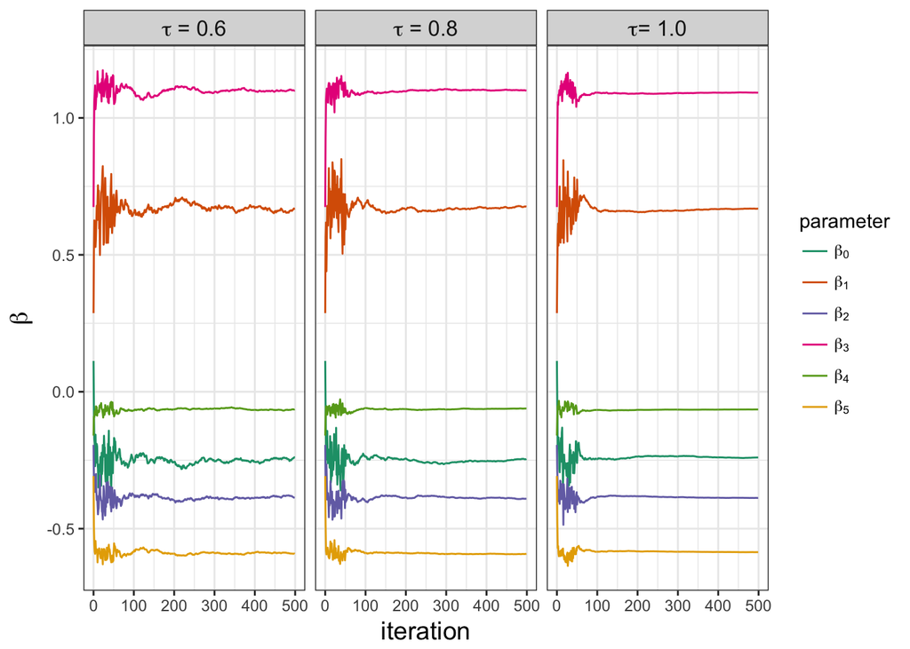

```r
df1 <- as.data.frame(t(list.saem0.6$seqbeta))
names(df1) <- paste0("beta[",0:5,"]")
df1['iteration'] <- 0:(nrow(df1)-1)
df1 <- melt(df1, variable.name="parameter", id.vars = list("iteration"))
df1['tau'] = fnames[1]
df2 <- as.data.frame(t(list.saem0.8$seqbeta))
names(df2) <- paste0("beta[",0:5,"]")
df2['iteration'] <- 0:(nrow(df2)-1)
df2 <- melt(df2, variable.name="parameter", id.vars = list("iteration"))
df2['tau'] = fnames[2]
df3 <- as.data.frame(t(list.saem1.0$seqbeta))
names(df3) <- paste0("beta[",0:5,"]")
df3['iteration'] <- 0:(nrow(df3)-1)
df3 <- melt(df3, variable.name="parameter", id.vars = list("iteration"))
df3['tau'] = fnames[3]

df <- rbind(df1, df2, df3)
df[['tau']] <- factor(df[['tau']], levels=fnames)
levels(df[['tau']]) <- c("tau*' = 0.6'", "tau*' = 0.8'", "tau*'= 1.0'")

beta2 <- subset(df, iteration==maxruns)
beta1 <- beta2
beta1$iteration <- 0
beta <- rbind(beta1, beta2)

ldf <- levels(df$parameter)
labl <- list(expression(beta[0]), expression(beta[1]), expression(beta[2]),
             expression(beta[3]), expression(beta[4]), expression(beta[5]) )

palette(brewer.pal(6, "Dark2"))
pl <- ggplot(df) + geom_line(aes(iteration,value,color=parameter)) +
#  geom_line(data=beta, aes(iteration, value, color=replicate)) +
  facet_grid(~tau, labeller = label_parsed) +  ylab(expression(beta)) +
  scale_color_manual(labels = labl, values=1:6) +
  theme(strip.text = element_text(size=12), axis.title=element_text(size=14))
print(pl)
```